# Prediction of Barbell Lift Classification

Brian Werner

March 27, 2016

*Prediction of Barbell Lift Classification*

**Introduction** Using devices such as Jawbone Up, Nike FuelBand, and Fitbit it is now possible to collect a large amount of data about personal activity relatively inexpensively. These type of devices are part of the quantified self movement – a group of enthusiasts who take measurements about themselves regularly to improve their health, to find patterns in their behavior, or because they are tech geeks. One thing that people regularly do is quantify how much of a particular activity they do, but they rarely quantify how well they do it. In this project, your goal will be to use data from accelerometers on the belt, forearm, arm, and dumbell of 6 participants. They were asked to perform barbell lifts correctly and incorrectly in 5 different ways.

```r
library(caret)
library(plyr)
library(dplyr)
training <- read.csv("pml-training.csv")
trainingClean <- training[,colSums(is.na(training))==0]
```

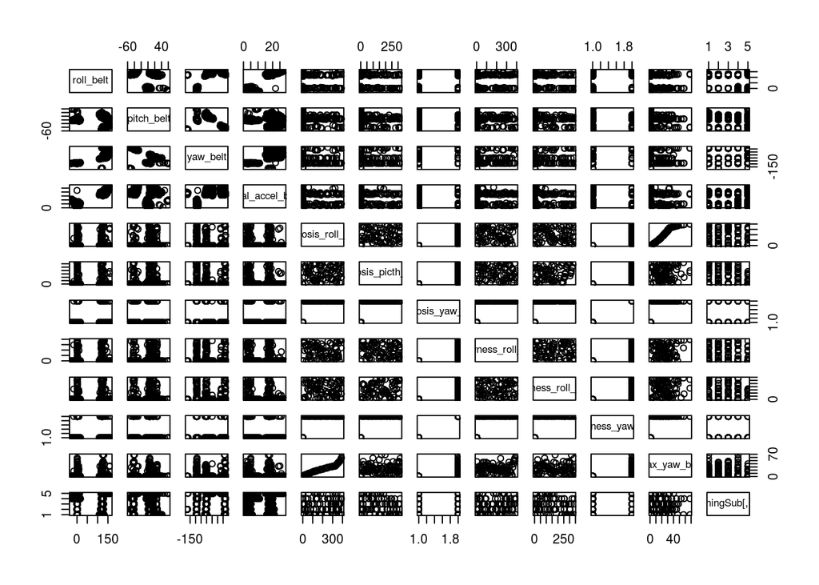

```r
trainSubset <- createDataPartition(trainingClean$classe,p=0.2,list=FALSE)
trainingSub <- trainingClean[trainSubset,]
pairsDF <- cbind(trainingSub[,8:18],trainingSub[,93])
pairs(pairsDF)
```

This procedure was reiterated through the entire balance of columns. Following these iterations I picked the following predictors: trainingClean, pitch_belt, max_yaw_belt, min_yaw_belt, gyros_belt_x, gyros_belt_y, gyros_belt_z, magnet_belt_x, magnet_belt_y, roll_arm, pitch_arm,yaw_arm, total_accel_arm, gyros_arm_x, gyros_arm_y, accel_arm_y, accel_arm_z, magnet_arm_y, max_yaw_dumbbell, min_yaw_dumbbell, total_accel_dumbbell, gyros_dumbbell_x, gyros_dumbbell_x, gyros_dumbbell_z, accel_dumbbell_x, accel_dumbbell_y, magnet_dumbbell_x, magnet_dumbbell_y, magnet_dumbbell_z, pitch_forearm, gyros_forearm_x, gyros_forearm_y, gyros_forearm_z, accel_forearm_x, accel_forearm_z, magnet_forearm_x, magnet_forearm_y, and magnet_forearm_z. From those chosen a GBM model was trained using the train function from the caret package.

```r
trainingChosen <- select(trainingClean,pitch_belt,max_yaw_belt,min_yaw_belt,gyros_belt_x,gyros_belt_y,gyros_belt_z,magnet_belt_x,magnet_belt_y,roll_arm,pitch_arm,yaw_arm,total_accel_arm,gyros_arm_x,gyros_arm_y,accel_arm_y,accel_arm_z,magnet_arm_y,max_yaw_dumbbell,min_yaw_dumbbell,total_accel_dumbbell,gyros_dumbbell_x,gyros_dumbbell_x,gyros_dumbbell_z,accel_dumbbell_x,accel_dumbbell_y,magnet_dumbbell_x,magnet_dumbbell_y,magnet_dumbbell_z,pitch_forearm,gyros_forearm_x,gyros_forearm_y,gyros_forearm_z,accel_forearm_x,accel_forearm_z,magnet_forearm_x,magnet_forearm_y,magnet_forearm_z,classe)
```

This run created a long list of warnings. Examining these warnings showed that several prediction variables that were included were not used in the model. These variables were removed and the model was retrained. Additionally, repeated cross validation was included in this training run.

```r
trainingChosen <- select(trainingChosen,-min_yaw_belt,-max_yaw_belt)
trainingChosen <- select(trainingChosen,-min_yaw_dumbbell,-max_yaw_dumbbell)
tControl <- trainControl(method="repeatedcv",number=4,repeats=2)
gbm_model <- train(classe ~ .,data=trainingChosen,method="gbm",trControl=tControl,verbose=FALSE)
```

This train run resulted without any errors or warnings in this instance.

```r
max_accuracy <- gbm_model$results[gbm_model$results$Accuracy==max(gbm_model$results$Accuracy),]
max_accuracy$Accuracy
```

```
## [1] 0.924345
```

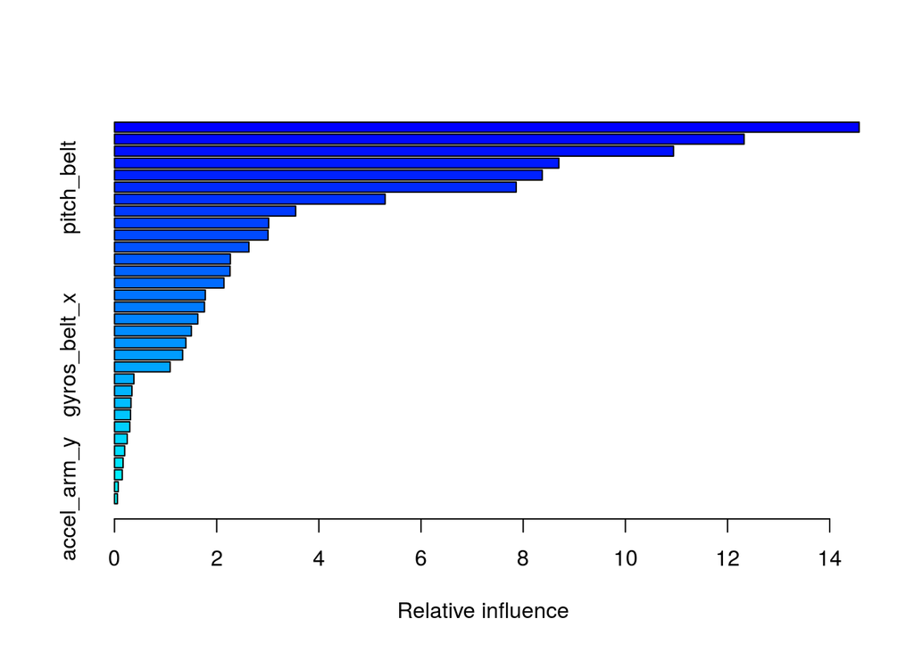

```
##                                       var     rel.inf
## pitch_forearm               pitch_forearm 14.57635947
## magnet_belt_y               magnet_belt_y 12.32514706
## magnet_dumbbell_z       magnet_dumbbell_z 10.94290536
## magnet_dumbbell_y       magnet_dumbbell_y  8.69785084
## gyros_belt_z                 gyros_belt_z  8.37339965
## pitch_belt                     pitch_belt  7.86322924
## accel_dumbbell_y         accel_dumbbell_y  5.29787711
## accel_forearm_z           accel_forearm_z  3.54628136
## accel_forearm_x           accel_forearm_x  3.01739086
## accel_dumbbell_x         accel_dumbbell_x  3.00553846
## magnet_dumbbell_x       magnet_dumbbell_x  2.63108514
## yaw_arm                           yaw_arm  2.26775378
## magnet_belt_x               magnet_belt_x  2.26232228
## total_accel_dumbbell total_accel_dumbbell  2.14315908
## magnet_arm_y                 magnet_arm_y  1.77703963
## magnet_forearm_z         magnet_forearm_z  1.76068322
## gyros_belt_y                 gyros_belt_y  1.63093486
## roll_arm                         roll_arm  1.50475568
## magnet_forearm_x         magnet_forearm_x  1.39737238
## gyros_belt_x                 gyros_belt_x  1.33380136
## gyros_arm_y                   gyros_arm_y  1.08922887
## gyros_dumbbell_z         gyros_dumbbell_z  0.37920614
## gyros_forearm_z           gyros_forearm_z  0.34186062
## gyros_dumbbell_x         gyros_dumbbell_x  0.32267684
## pitch_arm                       pitch_arm  0.31426398
## accel_arm_z                   accel_arm_z  0.29990416
## magnet_forearm_y         magnet_forearm_y  0.24917364
## gyros_arm_x                   gyros_arm_x  0.19977443
## total_accel_arm           total_accel_arm  0.16785827
## gyros_forearm_x           gyros_forearm_x  0.15142678
## gyros_forearm_y           gyros_forearm_y  0.07298958
## accel_arm_y                   accel_arm_y  0.05674986
```

```r
summary(gbm_model,rownames(max_accuracy))
```

**Results**

The resulting prediction is:

```r
testing <- read.csv("pml-testing.csv")
predict(gbm_model,testing)
```

```
##  [1] B A B A A C D B A A A C B A E E A B B B
## Levels: A B C D E
```